# Midterm

Andrew Chou

11 October 2021

## Question 1: Read in Data

```r
library(tidyverse)
resale1 <- read_csv("../data/resale1.csv")
resale2 <- read_csv("../data/resale2.csv")

# function to convert yr mo to years
to_year <- function(s) {
  year <- as.numeric(substr(s, 1, 2))
  month <- 0
  if (nchar(s) > 9) {
    month <- as.numeric(substr(s, 10, 11))
  }
  return(year + month / 12)
}

to_year <- Vectorize(to_year)

resale2 <- resale2 %>% mutate(remaining_lease = to_year(remaining_lease))

resale_prices <- bind_rows(resale1, resale2)

# check distinct values
resale_prices <- resale_prices %>% mutate(town = toupper(town))
dim(resale_prices %>% distinct(town))
```

```
## [1] 26  1
```

```r
dim(resale_prices %>% distinct(flat_type))
```

```
## [1] 7 1
```

```r
dim(resale_prices %>% distinct(flat_model))
```

```
## [1] 20  1
```

```r
summary(resale_prices)
```

```
##     month               town            flat_type            block
##  Length:146942      Length:146942      Length:146942      Length:146942
##  Class :character   Class :character   Class :character   Class :character
##  Mode  :character   Mode  :character   Mode  :character   Mode  :character
##
##
##
##  street_name        storey_range       floor_area_sqm    flat_model
##  Length:146942      Length:146942      Min.   : 31.00   Length:146942
##  Class :character   Class :character   1st Qu.: 82.00   Class :character
##  Mode  :character   Mode  :character   Median : 95.00   Mode  :character
##                                        Mean   : 97.63
##                                        3rd Qu.:113.00
##                                        Max.   :280.00
##  lease_commence_date remaining_lease  resale_price
##  Min.   :1966        Min.   : 0.00   Min.   : 140000
##  1st Qu.:1984        1st Qu.:64.75   1st Qu.: 340000
##  Median :1993        Median :74.42   Median : 420000
##  Mean   :1994        Mean   :74.65   Mean   : 450635
##  3rd Qu.:2003        3rd Qu.:84.00   3rd Qu.: 525000
##  Max.   :2019        Max.   :97.75   Max.   :1295000
```

```r
# The minimum remaining lease is 0 years. This could be a mistake. The minimum possible remaining lease you be at least 43 years since Singapore is only 56 years old. Let's fix it.

wrong_row <- which(resale_prices$remaining_lease < 43)
resale_prices[wrong_row,]
```

```
## # A tibble: 1 x 11
##   month   town  flat_type block street_name storey_range floor_area_sqm flat_model
##   <chr>   <chr> <chr>     <chr> <chr>       <chr>                 <dbl> <chr>
## 1 2020-12 ANG ~ 3 ROOM    425   ANG MO KIO~ 01 TO 03                 73 New Gener~
## # ... with 3 more variables: lease_commence_date <dbl>, remaining_lease <dbl>,
## #   resale_price <dbl>
```

```r
resale_prices[wrong_row, "remaining_lease"] <- 1979 + 99 - 2020

summary(resale_prices$remaining_lease)
```

```
##    Min. 1st Qu.  Median    Mean 3rd Qu.    Max.
##   44.33   64.75   74.42   74.65   84.00   97.75
```

```r
# check distinct months
resale_prices %>% distinct(month) %>% pull(1)
```

```
##  [1] "2015-01"  "2015-02"  "2015-03"  "2015-04"  "2015-05"  "2015-06"
##  [7] "2015-07"  "2015-08"  "2015-09"  "2015-10"  "2015-11"  "2015-12"
## [13] "2016-01"  "2016-02"  "2016-03"  "2016-04"  "2016-05"  "2016-06"
## [19] "2016-07"  "2016-08"  "2016-09"  "2016-10"  "2016-11"  "2016-12"
## [25] "2017-01"  "2017-02"  "2017-03"  "2017-04"  "2017-05"  "2017-06"
## [31] "2017-07"  "2017-08"  "2017-09"  "2017-10"  "2017-11"  "2017-12"
## [37] "2018-01"  "2018-02"  "2018-03"  "2018-04"  "2018-05"  "2018-06"
## [43] "2018-07"  "2018-08"  "2018-09"  "2018-10"  "2018-11"  "2018-12"
## [49] "2019-01"  "2019-02"  "2019-03"  "2019-04"  "2019-05"  "2019-06"
## [55] "2019-07"  "2019-08"  "2019-09"  "2019-10"  "2019-11"  "2019-12"
## [61] "2020-01"  "2020-02"  "2020-03"  "2020-04"  "2020-05"  "2020-06"
## [67] "2020-07"  "2020-Aug" "2020-09"  "2020-10"  "2020-11"  "2020-12"
## [73] "2021-01"  "2021-02"  "2021-03"  "2021-04"  "2021-05"  "2021-06"
## [79] "2021-07"  "2021-08"  "2021-09"  "2021-10"
```

```r
# replace "2020-Aug" with "2020-08"
resale_prices <- resale_prices %>% mutate(month = replace(month, month == "2020-Aug", "2020-08"))

resale_prices %>% distinct(month) %>% pull(1)
```

```
##  [1] "2015-01" "2015-02" "2015-03" "2015-04" "2015-05" "2015-06" "2015-07"
##  [8] "2015-08" "2015-09" "2015-10" "2015-11" "2015-12" "2016-01" "2016-02"
## [15] "2016-03" "2016-04" "2016-05" "2016-06" "2016-07" "2016-08" "2016-09"
## [22] "2016-10" "2016-11" "2016-12" "2017-01" "2017-02" "2017-03" "2017-04"
## [29] "2017-05" "2017-06" "2017-07" "2017-08" "2017-09" "2017-10" "2017-11"
## [36] "2017-12" "2018-01" "2018-02" "2018-03" "2018-04" "2018-05" "2018-06"
## [43] "2018-07" "2018-08" "2018-09" "2018-10" "2018-11" "2018-12" "2019-01"
## [50] "2019-02" "2019-03" "2019-04" "2019-05" "2019-06" "2019-07" "2019-08"
## [57] "2019-09" "2019-10" "2019-11" "2019-12" "2020-01" "2020-02" "2020-03"
## [64] "2020-04" "2020-05" "2020-06" "2020-07" "2020-08" "2020-09" "2020-10"
## [71] "2020-11" "2020-12" "2021-01" "2021-02" "2021-03" "2021-04" "2021-05"
## [78] "2021-06" "2021-07" "2021-08" "2021-09" "2021-10"
```

## Question 2: Create/Modify Columns

```r
# function to extract int from string
to_int <- function(s, start, end) {
  return(as.numeric(substr(s, start, end)))
}
to_int <- Vectorize(to_int)

resale_prices <- resale_prices %>% mutate(price_psm = resale_price / floor_area_sqm, lstorey = to_int(storey_range, 1, 2), ustorey = to_int(storey_range, 7, 8), year = to_int(month, 1, 4), month = to_int(month, 6, 7), town = replace(town, town == "KALLANG/WHAMPOA", "CENTRAL AREA"))

summary(resale_prices)
```

```
##      month            town            flat_type            block
##  Min.   : 1.000   Length:146942      Length:146942      Length:146942
##  1st Qu.: 4.000   Class :character   Class :character   Class :character
##  Median : 7.000   Mode  :character   Mode  :character   Mode  :character
##  Mean   : 6.574
##  3rd Qu.: 9.000
##  Max.   :12.000
##  street_name        storey_range       floor_area_sqm    flat_model
##  Length:146942      Length:146942      Min.   : 31.00   Length:146942
##  Class :character   Class :character   1st Qu.: 82.00   Class :character
##  Mode  :character   Mode  :character   Median : 95.00   Mode  :character
##                                        Mean   : 97.63
##                                        3rd Qu.:113.00
##                                        Max.   :280.00
##  lease_commence_date remaining_lease  resale_price       price_psm
##  Min.   :1966        Min.   :44.33   Min.   : 140000   Min.   : 2090
##  1st Qu.:1984        1st Qu.:64.75   1st Qu.: 340000   1st Qu.: 3856
##  Median :1993        Median :74.42   Median : 420000   Median : 4357
##  Mean   :1994        Mean   :74.65   Mean   : 450635   Mean   : 4654
##  3rd Qu.:2003        3rd Qu.:84.00   3rd Qu.: 525000   3rd Qu.: 5077
##  Max.   :2019        Max.   :97.75   Max.   :1295000   Max.   :12903
##     lstorey          ustorey            year
##  Min.   : 1.000   Min.   : 3.000   Min.   :2015
##  1st Qu.: 4.000   1st Qu.: 6.000   1st Qu.:2016
##  Median : 7.000   Median : 9.000   Median :2018
##  Mean   : 7.564   Mean   : 9.564   Mean   :2018
##  3rd Qu.:10.000   3rd Qu.:12.000   3rd Qu.:2020
##  Max.   :49.000   Max.   :51.000   Max.   :2021
```

```r
dim(resale_prices %>% distinct(town))
```

```
## [1] 25  1
```

## Question 3: Dealing with Inflation

```r
cpi_table <- read_csv("../data/cpi.csv")
resale_prices <- resale_prices %>% left_join(cpi_table, by = c("year", "month")) %>% mutate(price_psm_adj = price_psm / cpi * 100)

q3 <- resale_prices %>% filter(flat_type == "4 ROOM") %>% group_by(year, month) %>% summarize(Unadjusted = median(price_psm), Adjusted = median(price_psm_adj)) %>% drop_na() %>% pivot_longer(!c(year, month), names_to = "type", values_to = "price") %>% mutate(full_month = as.Date(paste0(year, "-", month, "-01")))
```

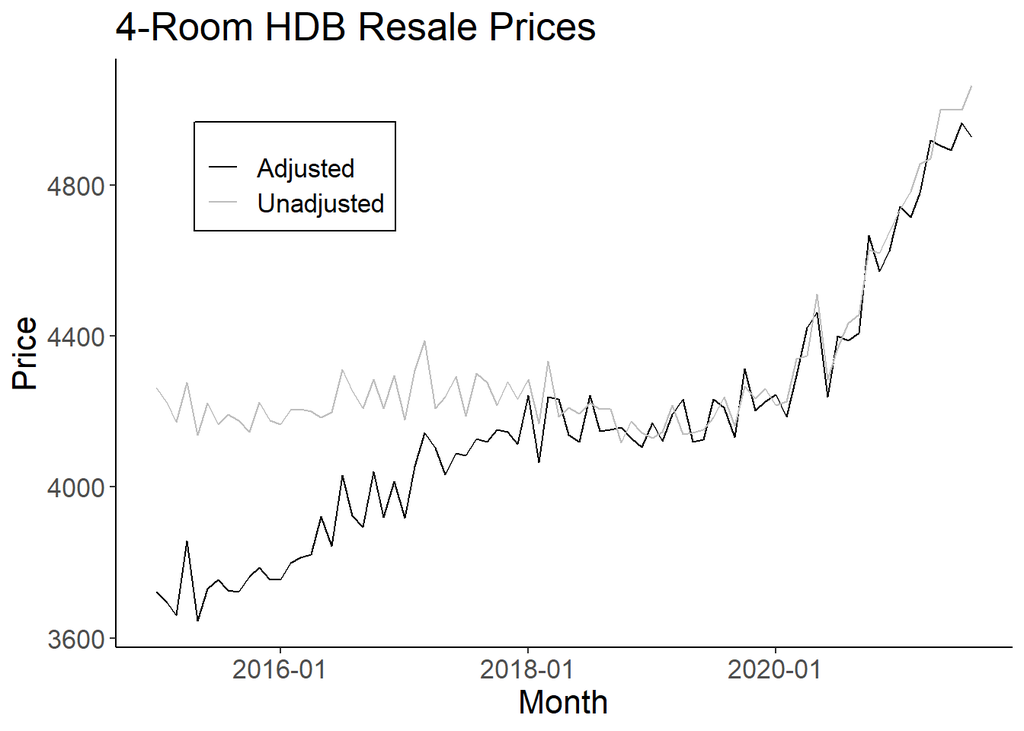

```r
ggplot(data = q3, aes(full_month, price, color = type)) + geom_line() + scale_x_date(date_labels = "%Y-%m", breaks = "2 years") + theme_classic() + xlab("Month") + ylab("Price") + ggtitle("4−Room HDB Resale Prices") + scale_color_manual(values=c("black", "grey")) + theme(legend.position = c(0.2, 0.8), legend.title = element_blank(), legend.background = element_rect( size=0.5, linetype="solid", color = "black"), text = element_text(size = 16))
```

## Question 4: Median Price by Town

```r
med_price_town_tbl <- resale_prices %>% filter(flat_type == "4 ROOM", year >= 2020) %>% group_by(town) %>% drop_na() %>% summarize(median_price_adj = median(price_psm_adj))

med_price_town_tbl
```

```
## # A tibble: 25 x 2
##    town          median_price_adj
##    <chr>                    <dbl>
##  1 ANG MO KIO               4468.
##  2 BEDOK                    4477.
##  3 BISHAN                   5517.
##  4 BUKIT BATOK              3922.
##  5 BUKIT MERAH              7569.
##  6 BUKIT PANJANG            4573.
##  7 BUKIT TIMAH              6203.
##  8 CENTRAL AREA             6119.
##  9 CHOA CHU KANG            4084.
## 10 CLEMENTI                 5827.
## # ... with 15 more rows
```

## Question 5: Robust Slopes

```r
plm <- function(x, y) {
  x_pairs <- combn(x, 2)
  y_pairs <- combn(y, 2)
  slope <- (y_pairs[2,] - y_pairs[1,]) / (x_pairs[2,] - x_pairs[1,])
  #remove inf and nan
  slope <- slope[!is.na(slope) & !is.infinite(slope)]
  b_hat <- median(slope)
  a <- y - b_hat * x
  a_hat <- median(a)
  return(c(b_hat, a_hat))
}

# Example data
x <- c(-4:3, 12); y <- c(0,0,0,0,0,0,-5, 5, 1)
(ba <- plm(x,y)) # fitted slope and intercept
```

```
## [1] 0 0
```

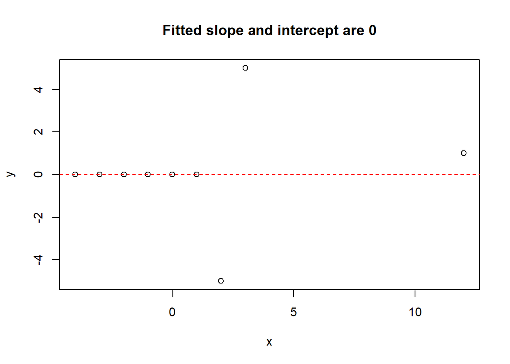

```r
plot(x,y, main="Fitted slope and intercept are 0")
abline(a=ba[2], b=ba[1], lty=2, col="red")
```

## Question 6: Rate of price increase by location

```r
q6 <- resale_prices %>% filter(flat_type == "4 ROOM", year >= 2020) %>% group_by(year, month, town) %>% drop_na() %>% summarize(median_price_psm_adj = median(price_psm_adj)) %>% mutate(month_num = (year - 2020) * 12 + month)
calc_town_inc_rate <- function(t) {
  x <- q6 %>% filter(town == t) %>% pull(5)
  y <- q6 %>% filter(town == t) %>% pull(4)
  r <- plm(x, y)
  return(r[1])
}

calc_town_inc_rate <- Vectorize(calc_town_inc_rate)

all_towns <- resale_prices %>% distinct(town) %>% pull(1)

q6_res <- calc_town_inc_rate(all_towns)

head(sort(q6_res, decreasing = TRUE), 3)
```

```
## CHOA CHU KANG      CLEMENTI  CENTRAL AREA
##      92.69136      84.05157      83.61314
```

```r
head(sort(q6_res), 3)
```

```
##     SERANGOON MARINE PARADE   BUKIT TIMAH
##     0.5052706     6.2659109     8.9527489
```

CHOA CHU KANG, CLEMENTI, and CENTRAL AREA had the greatest rate of increase with 93, 84, and 84 dollars per sqm per month respectively. SERANGOON, MARINE PARADE, and BUKIT TIMAH had the lowest rate of increase with 1, 6, and 9 dollars per sqm per month respectively.

## Question 7: Flat Models

```r
excluded_models <- setdiff((resale_prices %>% distinct(flat_model) %>% pull(1)), (resale_prices %>% filter(year >= 2020, flat_type == "4 ROOM")  %>% distinct(flat_model) %>% pull(1)))

zeroes_df <- data.frame(matrix(ncol = 8, nrow = 25))
colnames(zeroes_df) <- excluded_models

resale_prices %>% group_by(town, flat_model) %>% filter(year >= 2020, flat_type == "4 ROOM")  %>% summarize(count = n()) %>% complete() %>% pivot_wider(names_from = flat_model, values_from = count) %>% cbind(zeroes_df) %>% replace(is.na(.), 0)
```

```
## # A tibble: 25 x 21
## # Groups:   town [25]
##    town     DBSS `Model A` `New Generation` Improved `Premium Apartm~ Simplified
##    <chr>   <int>     <int>            <int>    <int>            <int>      <int>
##  1 ANG MO~    23       112              391        0                0          0
##  2 BEDOK      54       282              363       94               54         78
##  3 BISHAN     13       256               12        3               17        131
##  4 BUKIT ~     0       266              110        0               14         81
##  5 BUKIT ~     0       465               60       33                8         17
##  6 BUKIT ~     0       712                0        0              152         37
##  7 BUKIT ~     0        27                0       14                0          0
##  8 CENTRA~     9       241               47      109               16         13
##  9 CHOA C~     0       858               23        0               91          0
## 10 CLEMEN~   111       121              192        0                0          0
## # ... with 15 more rows, and 14 more variables: Model A2 <int>,
## #   Adjoined flat <int>, Standard <int>, Type S1 <int>,
## #   Premium Apartment Loft <int>, Terrace <int>, Maisonette <dbl>,
## #   Apartment <dbl>, Type S2 <dbl>, Model A-Maisonette <dbl>,
## #   Premium Maisonette <dbl>, Multi Generation <dbl>,
## #   Improved-Maisonette <dbl>, 2-room <dbl>
```

By manually inspecting the tibble, I discovered that Type S1 can only be found in CENTRAL AREA. Additionally, both Premium Apartment Loft and Terrace can only be found in QUEENSTOWN.

## Question 8: Adjust Planning Areas

```r
library(sf)
```

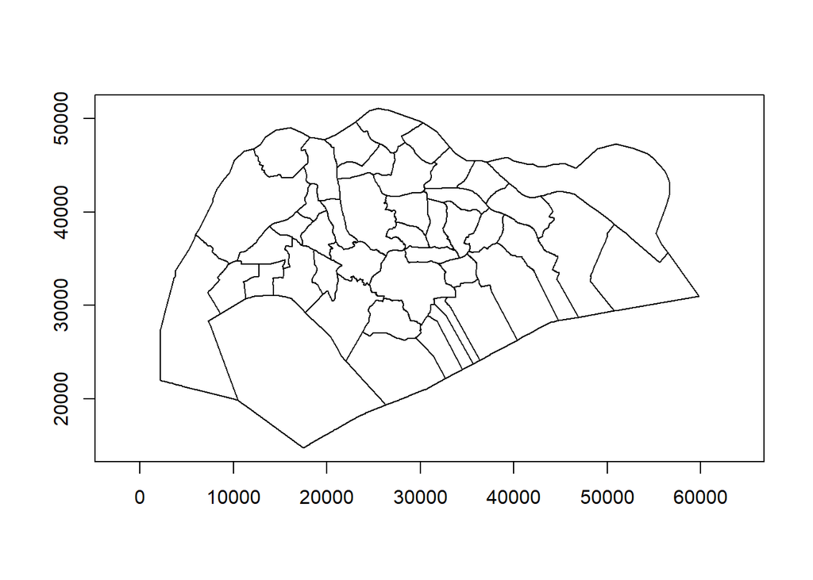

```r
pln <- read_rds("../data/sg_planning_areas.rds") %>% select(PLN_AREA_N, geometry)

central <- c("KALLANG", "NOVENA", "TANGLIN", "DOWNTOWN CORE", "MUSEUM", "NEWTON", "ORCHARD", "OUTRAM", "RIVER VALLEY", "ROCHOR", "SINGAPORE RIVER")

to_merge <- filter(pln, PLN_AREA_N %in% central)
merged <- st_union(to_merge)

pln_new <- filter(pln, !PLN_AREA_N %in% central)

pln_new[nrow(pln_new) + 1,] <- list("CENTRAL AREA", merged)
plot(st_geometry(pln_new), axes = TRUE)
```

## Question 9: Spatial Moving Averages

```r
pln_new <- pln_new %>% full_join(resale_prices %>% group_by(town) %>% filter(year == 2015, flat_type == "4 ROOM") %>% summarize(unsmoothed = median(price_psm_adj)), by = c("PLN_AREA_N" = "town"))

smoothing <- function(town) {
  town_geom <- pln_new[pln_new$PLN_AREA_N == town, ]
  neighbors <- st_touches(town_geom, pln_new)[[1]]
  mean(c(pln_new[neighbors, ]$unsmoothed, town_geom$unsmoothed), na.rm = TRUE)
}
smoothing <- Vectorize(smoothing)

q9 <- pln_new %>% mutate(smoothed = smoothing(PLN_AREA_N)) %>% drop_na()

pln_new <- pln_new %>% left_join(data.frame(q9 %>% select(PLN_AREA_N, smoothed)))
```

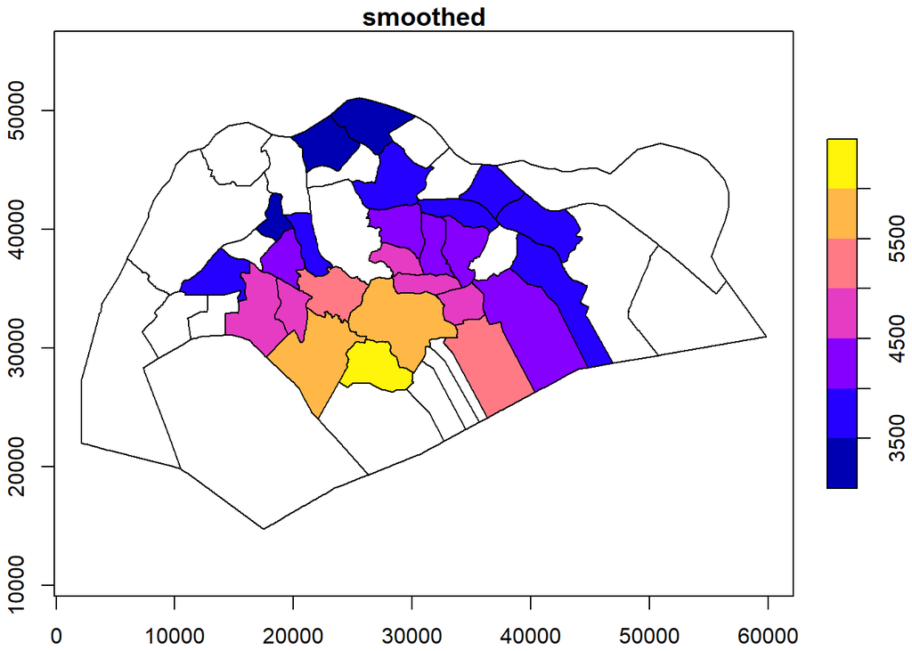

```r
plot(pln_new["smoothed"], axes = TRUE)
```

## Question 10: Discussion

To check if there is a growing demand of bigger flats, I will make a plot of median floor area vs time. To see if there will be a lesser demand for central locations, I can first calculate the proportions of transactions in the central area each month, then plot it against time. If the line is declining, then that is an evidence to support the claim. However, in question 6 we see that CENTRAL AREA has the third fastest growth rate in price in the past two years, which signifies a huge demand. I highly doubt that the demand for central locations will decrease anytime soon.